# The Correlation of Daily Sales for Tenant Synergy Analysis

Nabiilah Ardini Fauziyyah

8/16/2019

## Import Library

```r
library(tidyr)
library(dplyr)
library(lubridate)
```

## Read Data

To explain the process of using the correlation of daily sales/revenues for tenant synergy analysis, we use a dummy data:

```r
dummy <- read.csv("data_input/dummy-corr.csv") %>%
  mutate(Date = mdy(Date))
head(dummy)
```

|  | No | Tenant | Group | Date | Revenue |
| --- | --- | --- | --- | --- | --- |
| 1 | 1 | Chatime | F&B | 2019-01-01 | 72869986 |
| 2 | 2 | Chatime | F&B | 2019-01-02 | 71741411 |
| 3 | 3 | Chatime | F&B | 2019-01-03 | 71559865 |
| 4 | 4 | Chatime | F&B | 2019-01-04 | 71550219 |
| 5 | 5 | Chatime | F&B | 2019-01-05 | 80489319 |
| 6 | 6 | Chatime | F&B | 2019-01-06 | 85318228 |

Above is the report of daily revenues for each tenant. Below are the column descriptions:

- `No`: number of rows
- `Tenant`: name of tenant
- `Group`: group assigned for each tenant
- `Date`: date of daily sales recorded
- `Revenue`: daily sales/revenue

There are assumption applied in using this approach:

- assuming there is only one type of crowd
- assuming that each tenant has similar revenues ~ number of costumer: one type of tenant whose revenues is high may not give higher amount of costumer than the one which has lower revenues with lower price per item/services. This should be considered when finding the financial value (**size**) for each tenant.

## Tenant Significancies

Tenant significancies to a Mall (financial value) is represented by each tenant’s monthly revenue. It will be visualized using the node size later in the Tenants Graph using `visNetwork`.

```r
# calculating financial value
# financial value (size) = monthly revenue
size <- dummy %>%
  group_by(Tenant) %>%
  dplyr::summarize(Monthly_Revenue = mean(Revenue)) %>%
  arrange(desc(Monthly_Revenue)) %>%
  mutate(size = round(Monthly_Revenue*0.00000001,1))
size
```

| Tenant | Monthly_Revenue | size |
| --- | --- | --- |
| CGV | 84439462 | 0.8 |
| Uniqlo | 79639175 | 0.8 |
| Gramedia | 76765802 | 0.8 |
| Chatime | 72165403 | 0.7 |
| Pandora | 70666378 | 0.7 |
| Miniso | 60458432 | 0.6 |
| Celebrity Fitness | 51039843 | 0.5 |
| KOI | 49668896 | 0.5 |
| ZARA | 45838907 | 0.5 |
| Pull&Bear | 42743197 | 0.4 |

[output cut: 10 more lines]

## Corelation between Tenants

Correlation between tenants reflect the tenant synergy. We can visualize the correlation of daily sales for each tenant using `ggcorr()` from GGally package:

```r
# transform long into wide data format
dummy_cor <- dummy %>%
  select(Tenant,Date,Revenue) %>%
  spread(Tenant,Revenue)
dummy_cor
```

| Date | Celebrity Fitness | CGV | Chatime | Daiso | Erha Dermatologist | Fossil | Gramedia | Guardian | H&M | KOI | Kopi Kenangan | Miniso | Pandora | Pull&Bear | Sport Station | The Body Shop | The Executive | Uniqlo | Yoshinoya | ZARA |
| --- | --- | --- | --- | --- | --- | --- | --- | --- | --- | --- | --- | --- | --- | --- | --- | --- | --- | --- | --- | --- |
| 2019-01-01 | 44258437 | 87680824 | 72869986 | 15305028 | 33212901 | 13147675 | 80150942 | 23222813 | 42106512 | 36233244 | 19947462 | 66988046 | 72113199 | 44573030 | 66383307.1 | 44239788 | 24927458 | 70540435 | 32887551 | 45442213 |
| 2019-01-02 | 50724814 | 88473926 | 71741411 | 15224197 | 32232170 | 14149318 | 79524085 | 20674632 | 45848961 | 38013271 | 20528693 | 65020050 | 45351543 | 53590603 | 55876347.7 | 44029165 | 24972255 | 84799076 | 33980800 | 47318076 |
| 2019-01-03 | 58219417 | 86865894 | 71559865 | 17100769 | 30984911 | 14759297 | 83889309 | 18185098 | 38173784 | 39039782 | 25640197 | 64014757 | 48691281 | 42177656 | 53845516.2 | 43558053 | 25939242 | 74279507 | 34332331 | 44378490 |
| 2019-01-04 | 51096875 | 88967747 | 71550219 | 15182774 | 30863562 | 14826972 | 83628056 | 19262446 | 38986485 | 41557365 | 25695218 | 63952070 | 78332169 | 38083558 | 50717974.1 | 42368416 | 25804353 | 64487829 | 34437923 | 46895505 |
| 2019-01-05 | 44815491 | 89817927 | 80489319 | 14734818 | 30304577 | 15826175 | 82671059 | 21625093 | 39125305 | 43496567 | 26609275 | 63722119 | 83619588 | 48263525 | 48154641.1 | 42302128 | 27850058 | 79529479 | 34601360 | 45455606 |
| 2019-01-06 | 45753819 | 89543506 | 85318228 | 14822860 | 30228841 | 16416655 | 87237075 | 20069239 | 35378860 | 43799121 | 27416881 | 63278373 | 85526269 | 42432892 | 47749746.7 | 41797447 | 26563268 | 88754208 | 34814257 | 47349996 |
| 2019-01-07 | 48118096 | 86658389 | 71294119 | 14241793 | 30091331 | 17172517 | 84588204 | 19948280 | 38906545 | 44263538 | 28643716 | 63073201 | 50075175 | 42823666 | 47597721.5 | 40715787 | 26850067 | 85737294 | 34821738 | 45684598 |
| 2019-01-08 | 53383473 | 86599446 | 71173198 | 15934534 | 29802909 | 17175932 | 78840272 | 19778304 | 41690729 | 45218785 | 28821622 | 62453655 | 64409675 | 41464481 | 39679805.9 | 40106507 | 27184809 | 65060180 | 34989096 | 44776166 |
| 2019-01-09 | 53432852 | 85968346 | 71111345 | 15955144 | 29751696 | 17281178 | 78827008 | 20950242 | 44844967 | 46929054 | 28886810 | 62055335 | 76792218 | 45756812 | 39559224.5 | 39768107 | 25592544 | 92760229 | 35215058 | 47889676 |
| 2019-01-10 | 54453869 | 85839703 | 70807665 | 15335304 | 29556200 | 18672538 | 78812408 | 21162812 | 36267521 | 47108238 | 30152546 | 61955610 | 51137918 | 43536165 | 38968422.9 | 38577013 | 24722740 | 80839231 | 35435535 | 47276681 |

[output cut: 21 more lines]

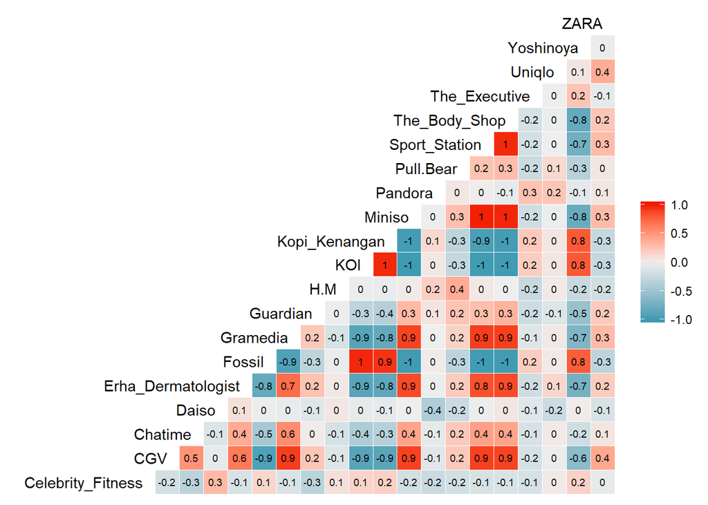

```r
library(GGally)

ggcorr(dummy_cor[,-1], # do not include the date column
       label = T,
       label_size = 2.5,
       hjust = 1, layout.exp = 5)
```

Transforming corelation result into data frame using `rcorr()` from Hmisc:

```r
library(Hmisc)
dummy_cor_m <- as.matrix(dummy_cor[,-1])
cor_matrix <- rcorr(dummy_cor_m)

# ++++++++++++++++++++++++++++
# flattenCorrMatrix
# ++++++++++++++++++++++++++++
# cormat : matrix of the correlation coefficients
# pmat : matrix of the correlation p-values

flattenCorrMatrix <- function(cormat) {
  ut <- upper.tri(cormat)
  data.frame(
    Tenant1 = rownames(cormat)[row(cormat)[ut]],
    Tenant2 = rownames(cormat)[col(cormat)[ut]],
    Correlation  =(cormat)[ut]
    )
}

flat_cor <- flattenCorrMatrix(cor_matrix$r) %>%
  filter(Correlation >= 0.5 | Correlation <= -0.5) # filter the observations which have strong enough correlation

cor_df <- flat_cor %>%
  mutate(width=ifelse(Correlation>0.5,Correlation,-Correlation),
         width=width^5*10,
         color=ifelse(Correlation>0.5,"Blue","Red"))

cor_df
```

| Tenant1 | Tenant2 | Correlation | width | color |
| --- | --- | --- | --- | --- |
| CGV | Chatime | 0.5143751 | 0.3600805 | Blue |
| CGV | Erha Dermatologist | 0.6463688 | 1.1282415 | Blue |
| CGV | Fossil | -0.9186073 | 6.5410806 | Red |
| Erha Dermatologist | Fossil | -0.8124613 | 3.5400834 | Red |
| CGV | Gramedia | 0.9116687 | 6.2977466 | Blue |
| Chatime | Gramedia | 0.5513045 | 0.5092811 | Blue |
| Erha Dermatologist | Gramedia | 0.7143821 | 1.8605993 | Blue |
| Fossil | Gramedia | -0.9166040 | 6.4700673 | Red |
| CGV | KOI | -0.8742134 | 5.1060750 | Red |
| Erha Dermatologist | KOI | -0.8731975 | 5.0764763 | Red |

[output cut: 38 more lines]

## Visualization Network

The financial value and tenant synergy can be visualized using visNetwork. Prior to visualization, a data pre-processing step is needed to match the column name and format:

```r
vn_nodes <- size %>%
  mutate(id = row_number(size)) %>%
  rename(label = Tenant,
         value = size) %>%
  select(id, label, value)

head(vn_nodes)
```

| id | label | value |
| --- | --- | --- |
| 18 | CGV | 0.8 |
| 19 | Uniqlo | 0.8 |
| 20 | Gramedia | 0.8 |
| 16 | Chatime | 0.7 |
| 17 | Pandora | 0.7 |
| 15 | Miniso | 0.6 |

```r
# prepare switching function from tenant name to tenant id
decode <- function(data){
  sapply(as.character(data), switch,
       "Fossil" = "1",
       "Guardian" = "2",
       "Daiso" = "3",
       "Kopi Kenangan" = "4",
       "Sport Station" = "5",
       "Erha Dermatologist" = "6",
       "The Executive" = "7",
       "Pull&Bear" = "8",
       "H&M" = "9",
       "The Body Shop" = "10",
       "Yoshinoya" = "11",
       "Celebrity Fitness" = "12",
       "KOI" = "13",
       "Zara" = "14",
       "Miniso" = "15",
       "Chatime" = "16",
       "Pandora" = "17",
       "CGV" = "18",
       "Uniqlo"= "19",
       "Gramedia" = "20")
}

vn_edges <- cor_df %>%
  rename(from = Tenant1,
         to = Tenant2) %>%
  mutate(from = decode(from),
         to = decode(to))

head(vn_edges)
```

|  | from | to | Correlation | width | color |
| --- | --- | --- | --- | --- | --- |
| 1 | 18 | 16 | 0.5143751 | 0.3600805 | Blue |
| 2 | 18 | 6 | 0.6463688 | 1.1282415 | Blue |
| 3 | 18 | 1 | -0.9186073 | 6.5410806 | Red |
| 4 | 6 | 1 | -0.8124613 | 3.5400834 | Red |
| 5 | 18 | 20 | 0.9116687 | 6.2977466 | Blue |
| 6 | 16 | 20 | 0.5513045 | 0.5092811 | Blue |

whereas: * node: represent each tenant * node size: represent the financial value of each tenant * line_width: correlation value (the higher the stronger) * line_color: correlation value (blue: positive, red: negative)

```r
library(visNetwork)
set.seed(100)
visNetwork(nodes=vn_nodes,edges=vn_edges,width="100%") %>%
  visLegend() %>%
  visOptions(nodesIdSelection = T,highlightNearest = T)
```

[interactive chart not shown]